# Mélodie Enigmatique

*Décrypter le Code de la Popularité Musicale*

Gabin SENGEL, Hugo COCHEREAU & Adam BELAMIRI

# Introduction :

- Quel est la recette musicale captivant le plus d’auditeurs en 2023 ?

Dans un premier temps, nous allons vous présenter une étude `quantitatives` de statistques de popularité et de cractéristiques musicales afin de déterminer si une musique fait de meilleurs stats en fonction de l’intensité de l’une de ses caractéristiques.

Ensuite, nous allons tenter d’identifier un lien entre le classement d’une musique et la saison de sa sortie par le biais d’une AFC.

Et pour finir, une étude `qualitative` tentera de déterminer un lien entre les caractéristiques musicales et le classement d’un morceau dans les charts au travers une ACM.

# Table des Matières :

- Introduction
- Base de données et décisions
- Statistiques descriptives
- ACP
- AFC
- ACM
- Classification
- Conclusion
- Remerciements

## Base de données et décisions :

- **Données** :
  - **Most Streamed Spotify Songs 2023**
  - `953` musiques observées au travers `24` variables
  - `145` données manquantes

## Description des variable :

| Nom des variables | Descriptiton |
| --- | --- |
| track_name | Le nom de la musique |
| artist_s_name | Le nom des artistes ayant collaboré C la création de la musique |
| artist_count | Le nombre d'artistes qui ont contribué à la chanson. |
| released_year | L'année de sortie de la chanson. |
| released_month | Le mois de sortie de la chanson. |
| released_day | Le jour du mois de sortie de la chanson. |
| in_spotify_playlists | Le nombre de playlists Spotify auxquelles la chanson est incluse. |
| in_spotify_charts | La présence et le classement de la chanson sur les classements Spotify.. |
| streams | Le nombre total de streams (écoutes) de la chanson sur Spotify. |
| in_apple_playlists | Le nombre de playlists Apple Music auxquelles la chanson est incluse. |

[output cut: 14 more lines]

## Importation

```r
df<-read_delim("data_frame_dossier/spotify-2023.csv",delim = ",",
               locale = locale(encoding = "latin1"))

df <- clean_names(df,"snake")

df <- df |>
  mutate(track_and_artist_name = paste(track_name,"_",artist_s_name)) |>
  select(track_and_artist_name,everything()) |>
  select(-track_name,-artist_s_name)

df <- df |> as_tibble() |>
  column_to_rownames(var = "track_and_artist_name")
```

Problèmes :

- `145` données manquantes:
  - `50` provenant de `in_shazam_chart`
  - `95` provenant de `key`
- Quelques données aberrantes (2762 streams pour 1 musique)
- Passage des musiques en individus

Solution :

- Considérer l’absence de données comme une modalité
- Non-utilisation des individus aberrants

## Quelques observations

- Résumé des variables quantitatives
- Répartition des featurings
- Répartition temporelle

Unique

Missing Pct.

Mean

SD

Min

Median

Max

Histogram

artist_count

8

0

1.6

0.9

1.0

1.0

8.0

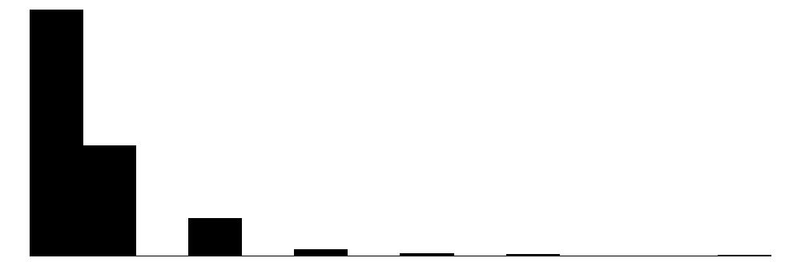

released_year

49

0

2018.5

10.8

1930.0

2022.0

2023.0

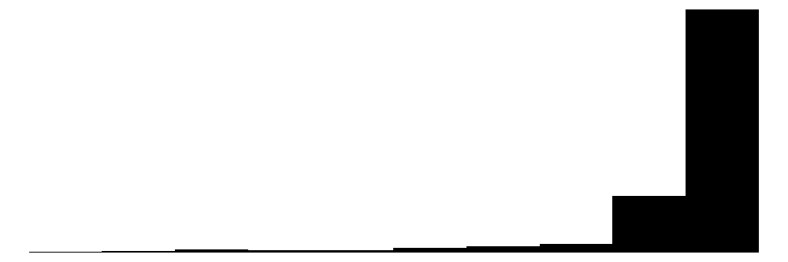

released_month

12

0

6.0

3.6

1.0

5.0

12.0

[figure not shown]

released_day

31

0

13.9

9.2

1.0

13.0

31.0

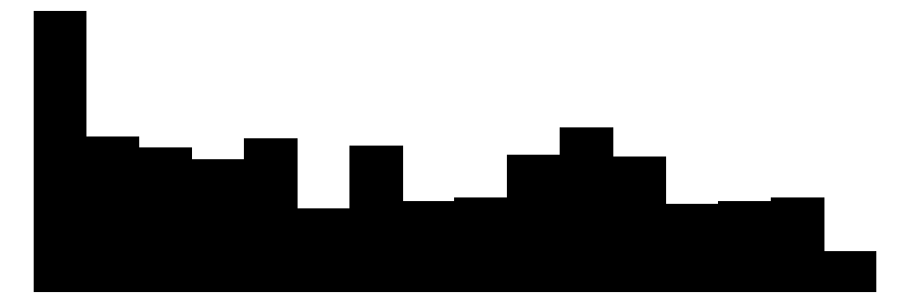

in_spotify_playlists

828

0

4800.0

7614.4

31.0

2008.5

52898.0

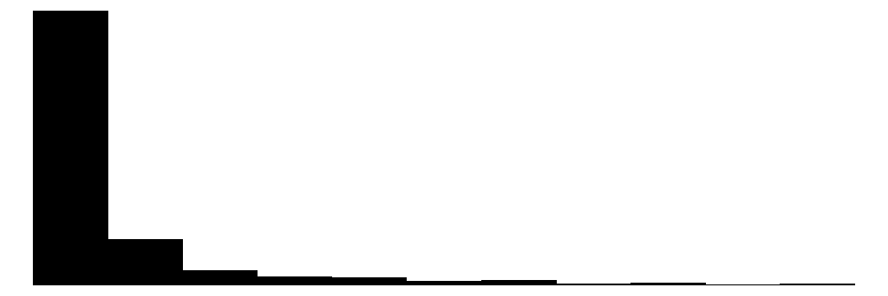

in_spotify_charts

80

0

11.9

19.2

0.0

3.0

147.0

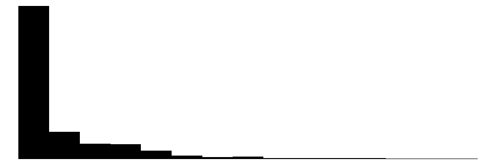

streams

898

0

469232350.7

519806487.6

2762.0

269727954.5

3562543890.0

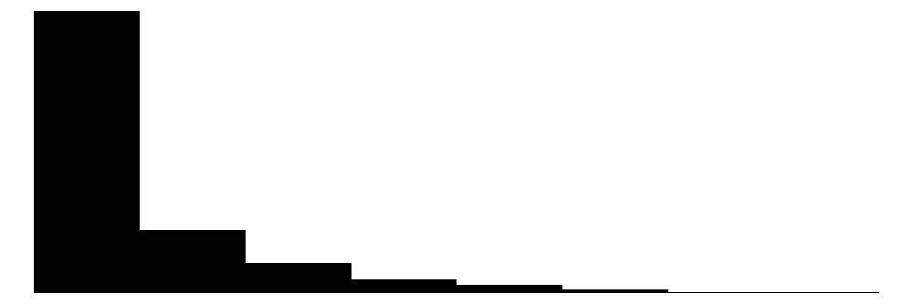

in_apple_playlists

214

0

60.5

75.1

0.0

32.0

532.0

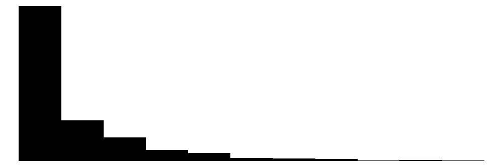

in_apple_charts

165

0

50.2

49.7

0.0

35.0

275.0

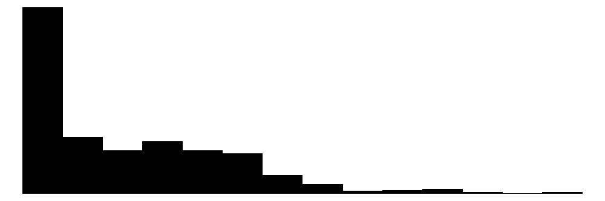

in_deezer_playlists

313

0

357.4

1120.7

0.0

40.0

12367.0

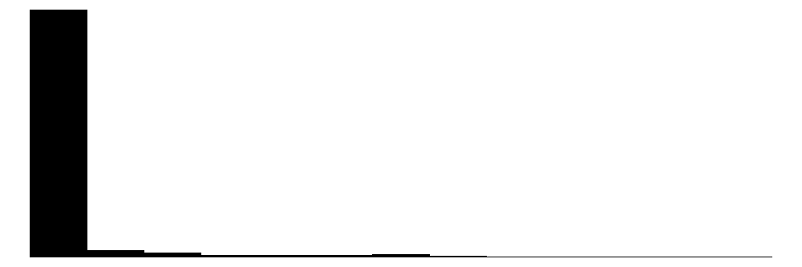

in_deezer_charts

32

0

2.5

5.8

0.0

0.0

58.0

[figure not shown]

in_shazam_charts

198

0

60.1

161.2

0.0

2.5

1451.0

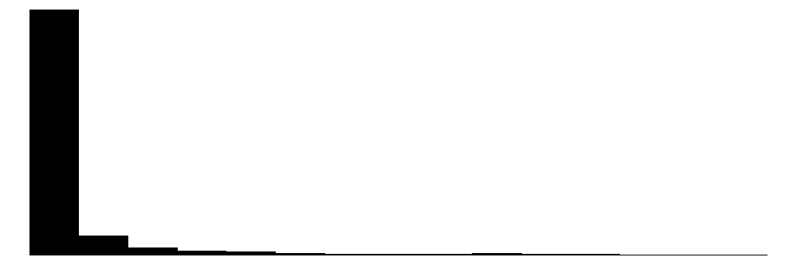

bpm

123

0

122.4

27.9

65.0

120.0

206.0

[figure not shown]

danceability_percent

71

0

67.2

14.7

23.0

69.0

96.0

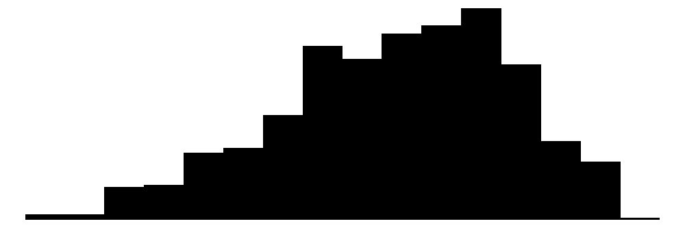

valence_percent

94

0

51.3

23.5

4.0

51.0

97.0

[figure not shown]

energy_percent

80

0

64.3

16.6

9.0

66.0

97.0

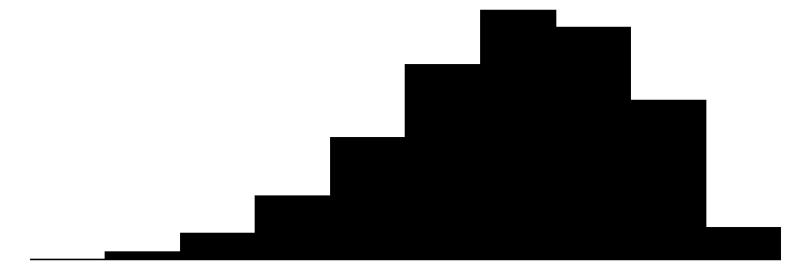

acousticness_percent

97

0

26.8

25.9

0.0

17.0

97.0

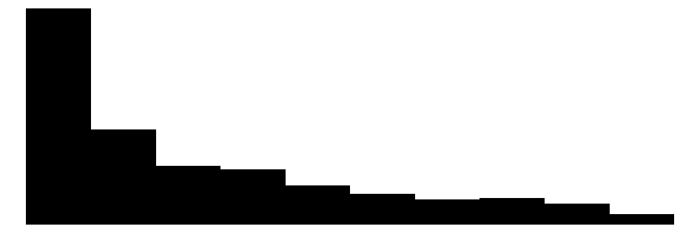

instrumentalness_percent

39

0

1.6

8.6

0.0

0.0

91.0

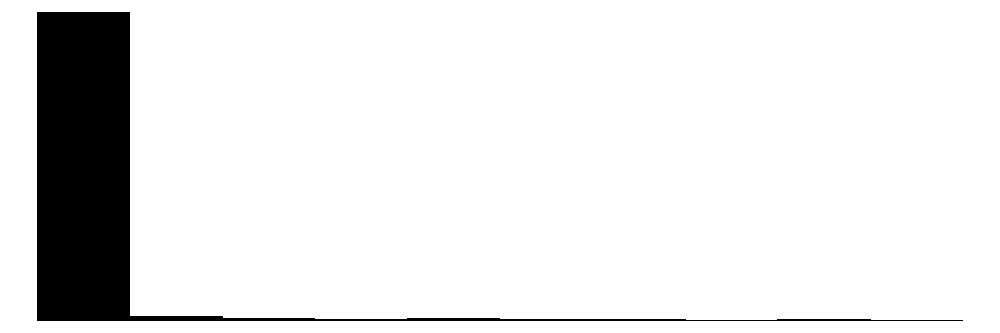

liveness_percent

67

0

18.2

13.7

3.0

12.0

97.0

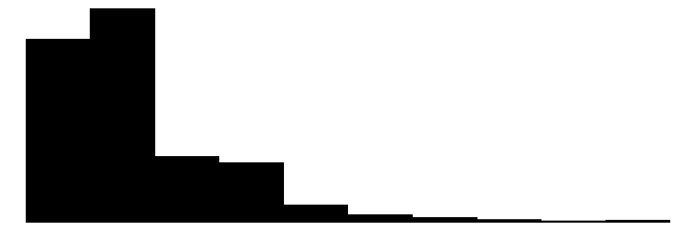

speechiness_percent

48

0

10.3

10.1

2.0

6.0

64.0

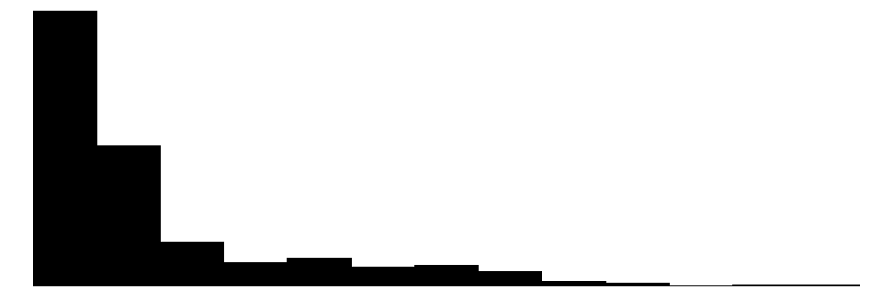

**Répartition des featurings**

| nombre.d.artistes | 1 | 2 | 3 | 4 | 5 | 6 | 7 | 8 |
| --- | --- | --- | --- | --- | --- | --- | --- | --- |
| Proportion | 0.61 | 0.27 | 0.09 | 0.02 | 0.01 | 0.00 | 0.00 | 0.00 |

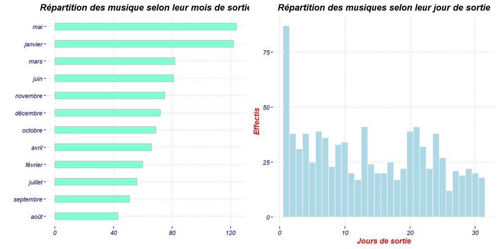

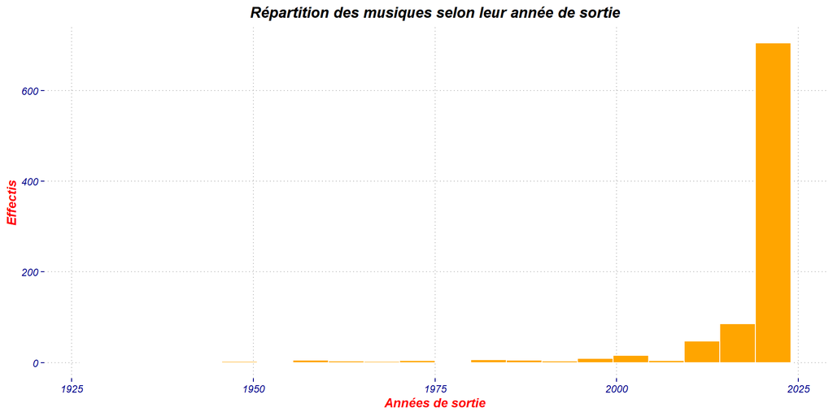

## Avant l’ACP

- Répartion des musiques selon leurs caractéristiques musicales
- Matrice des corrélations

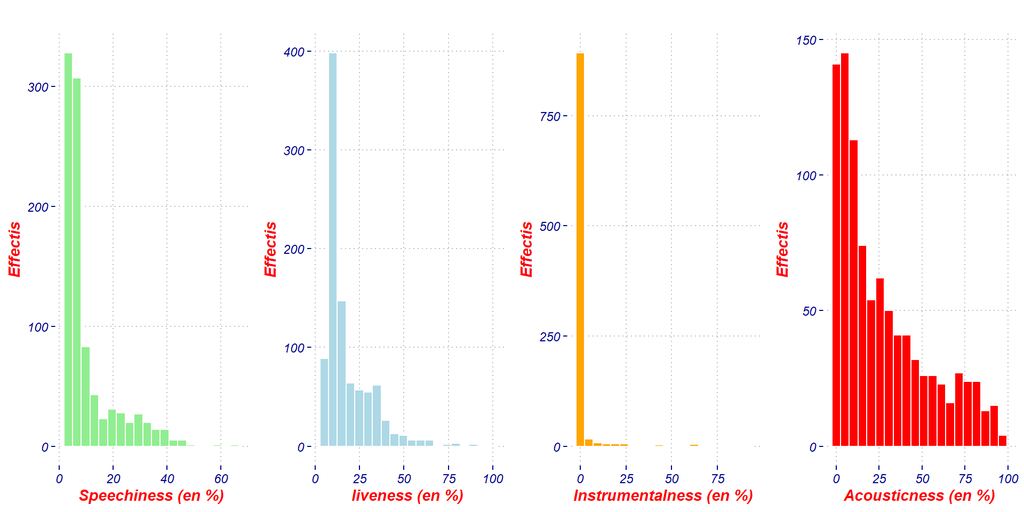

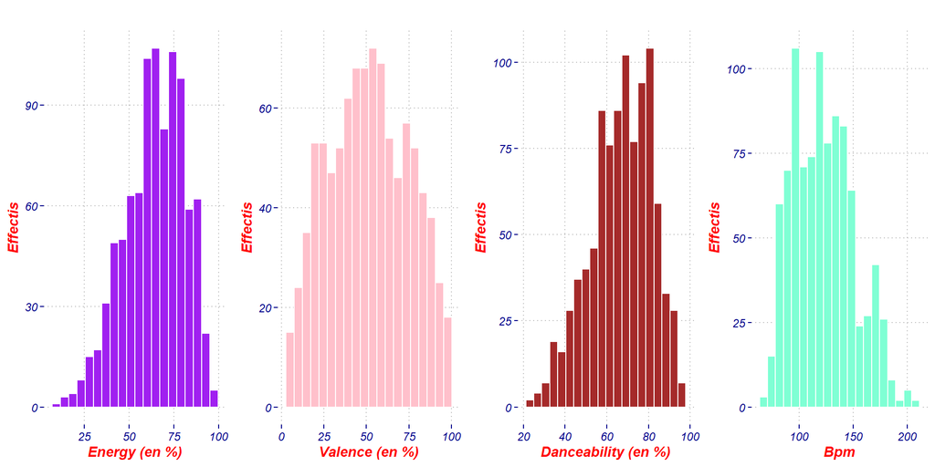

|  | artist_count | released_year | released_month | released_day | in_spotify_playlists | in_spotify_charts | streams | in_apple_playlists | in_apple_charts | in_deezer_playlists | in_deezer_charts | in_shazam_charts | bpm | danceability_percent | valence_percent | energy_percent | acousticness_percent | instrumentalness_percent | liveness_percent | speechiness_percent |
| --- | --- | --- | --- | --- | --- | --- | --- | --- | --- | --- | --- | --- | --- | --- | --- | --- | --- | --- | --- | --- |
| artist_count | 1 | 0.08 | 0.03 | -0.03 | -0.09 | 0 | -0.12 | -0.02 | -0.08 | -0.07 | 0.02 | -0.02 | -0.06 | 0.22 | 0.13 | 0.15 | -0.1 | -0.05 | 0.05 | 0.12 |
| released_year | 0.08 | 1 | 0.06 | 0.16 | -0.41 | 0.07 | -0.25 | -0.22 | -0.02 | -0.33 | 0.09 | 0.02 | -0.01 | 0.2 | -0.04 | 0.09 | -0.12 | -0.02 | 0.01 | 0.13 |
| released_month | 0.03 | 0.06 | 1 | 0.06 | -0.11 | -0.07 | -0.04 | -0.02 | -0.03 | -0.09 | -0.01 | -0.09 | -0.05 | -0.04 | -0.11 | -0.09 | 0.07 | 0.04 | -0.01 | 0.04 |
| released_day | -0.03 | 0.16 | 0.06 | 1 | -0.09 | 0 | -0.01 | 0.01 | 0.01 | -0.08 | 0.05 | 0.02 | -0.04 | 0.07 | 0.06 | 0.05 | 0 | 0.02 | 0.01 | -0.02 |
| in_spotify_playlists | -0.09 | -0.41 | -0.11 | -0.09 | 1 | 0.14 | 0.78 | 0.69 | 0.23 | 0.83 | 0.1 | 0.08 | -0.03 | -0.11 | -0.03 | 0.03 | -0.08 | -0.02 | -0.05 | -0.08 |
| in_spotify_charts | 0 | 0.07 | -0.07 | 0 | 0.14 | 1 | 0.21 | 0.21 | 0.56 | 0.07 | 0.59 | 0.6 | 0.02 | 0.05 | 0.05 | 0.08 | -0.06 | -0.01 | -0.05 | -0.08 |
| streams | -0.12 | -0.25 | -0.04 | -0.01 | 0.78 | 0.21 | 1 | 0.73 | 0.28 | 0.61 | 0.18 | 0.03 | -0.02 | -0.1 | -0.05 | -0.03 | -0.02 | -0.04 | -0.06 | -0.1 |
| in_apple_playlists | -0.02 | -0.22 | -0.02 | 0.01 | 0.69 | 0.21 | 0.73 | 1 | 0.37 | 0.47 | 0.35 | 0.16 | 0.01 | -0.01 | 0.05 | 0.05 | -0.09 | -0.05 | -0.06 | -0.1 |
| in_apple_charts | -0.08 | -0.02 | -0.03 | 0.01 | 0.23 | 0.56 | 0.28 | 0.37 | 1 | 0.14 | 0.38 | 0.43 | 0.02 | -0.02 | 0.05 | 0.11 | -0.09 | -0.01 | -0.01 | -0.15 |
| in_deezer_playlists | -0.07 | -0.33 | -0.09 | -0.08 | 0.83 | 0.07 | 0.61 | 0.47 | 0.14 | 1 | 0.05 | 0.08 | -0.04 | -0.08 | -0.02 | 0.07 | -0.08 | -0.01 | -0.02 | -0.05 |

[output cut: 10 more lines]

# ACP :

## Mise en place de l’ACP

- Inertie des axes
- Inerties cumulées

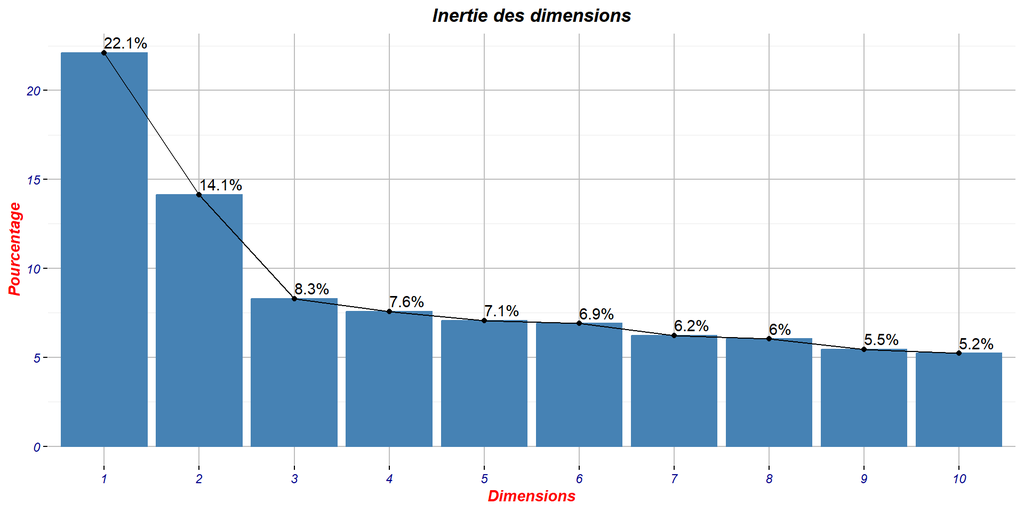

|  | comp 1 | comp 2 | comp 3 | comp 4 | comp 5 | comp 6 | comp 7 | comp 8 | comp 9 | comp 10 | comp 11 | comp 12 | comp 13 | comp 14 | comp 15 |
| --- | --- | --- | --- | --- | --- | --- | --- | --- | --- | --- | --- | --- | --- | --- | --- |
| eigenvalue | 3.32 | 2.12 | 1.24 | 1.14 | 1.06 | 1.03 | 0.93 | 0.90 | 0.82 | 0.78 | 0.55 | 0.51 | 0.30 | 0.20 | 0.10 |
| percentage of variance | 22.11 | 14.12 | 8.28 | 7.58 | 7.05 | 6.90 | 6.21 | 6.03 | 5.45 | 5.22 | 3.66 | 3.39 | 2.01 | 1.32 | 0.65 |
| cumulative percentage of variance | 22.11 | 36.23 | 44.52 | 52.10 | 59.15 | 66.05 | 72.26 | 78.29 | 83.75 | 88.96 | 92.62 | 96.01 | 98.03 | 99.35 | 100.00 |

## Etude des variables

- Nuage des variables
- Contributions

**Plan (1,2)**

[interactive chart not shown]

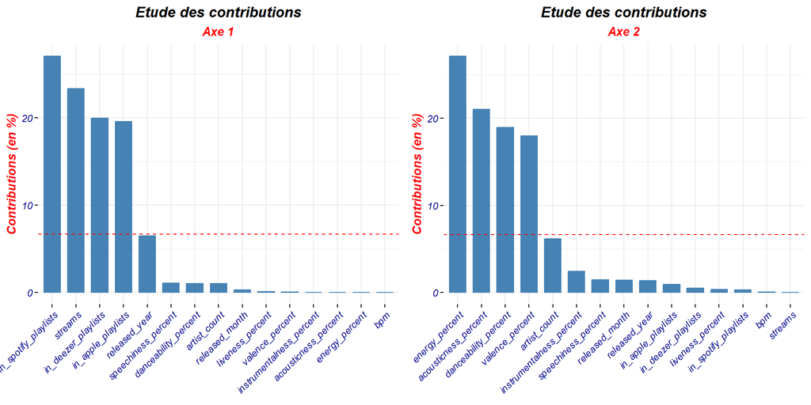

## Etude des individus

- Nuage des individus
- Contributions
- Musiques les plus écoutées

**Plan (1,2)**

[interactive chart not shown]

**Axe 1**

|  | X1 | X2 |
| --- | --- | --- |
| 623 | Smells Like Teen Spirit - Remastered 2021 _ Nirvana | 3.48 |
| 56 | Blinding Lights _ The Weeknd | 3 |
| 716 | Bohemian Rhapsody - Remastered 2011 _ Queen | 2.22 |
| 719 | Wake Me Up - Radio Edit _ Avicii | 2.16 |
| 629 | Mr. Brightside _ The Killers | 1.99 |
| 870 | Sweet Child O' Mine _ Guns N' Roses | 1.85 |
| 163 | Enchanted _ Taylor Swift | 1.74 |
| 756 | Get Lucky - Radio Edit _ Pharrell Williams, Nile Rodgers, Daft Punk | 1.69 |
| 619 | Dance Monkey _ Tones and I | 1.49 |
| 180 | Night Changes _ One Direction | 1.46 |

**Axe 2**

|  | X1 | X2 |
| --- | --- | --- |
| 461 | Wonderful Christmastime - Edited Version / Remastered 2011 _ Paul McCartney | 1.28 |
| 696 | Something In The Way - Remastered 2021 _ Nirvana | 1.26 |
| 18 | What Was I Made For? [From The Motion Picture "Barbie"] _ Billie Eilish | 1.03 |
| 939 | Sweet Nothing _ Taylor Swift | 0.98 |
| 470 | Driving Home for Christmas - 2019 Remaster _ Chris Rea | 0.97 |
| 388 | STAR WALKIN' (League of Legends Worlds Anthem) _ Lil Nas X | 0.96 |
| 690 | Forever _ Labrinth | 0.96 |
| 948 | Bigger Than The Whole Sky _ Taylor Swift | 0.91 |
| 908 | Static _ Steve Lacy | 0.91 |
| 800 | Crown _ Kendrick Lamar | 0.84 |

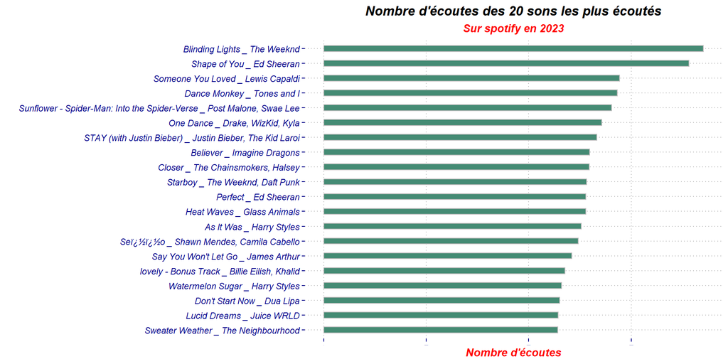

```
[1] 30
```

# AFC :

## Création des classes pour la variable in_spotify_charts

```r
dfAFC$top_spotify <- case_when(
    dfAFC$in_spotify_charts == 0 ~ 'pas classé',
    between(dfAFC$in_spotify_charts, 1, 5) ~ 'Top 5',
    between(dfAFC$in_spotify_charts, 6, 20) ~ 'Top 20',
    between(dfAFC$in_spotify_charts, 21, 50) ~ 'Top 50',
    between(dfAFC$in_spotify_charts, 51, 147) ~ 'supp 50',
    TRUE ~ 'pas classé')
```

| Valeur de la variable | [1;5] | [6;20] | [21;50] | [51,200] | pas classé |
| --- | --- | --- | --- | --- | --- |
| Classe associée | Top 5 | Top 20 | Top 50 | > 50 | 0 |

## Répartition de nos individus dans les variables actives

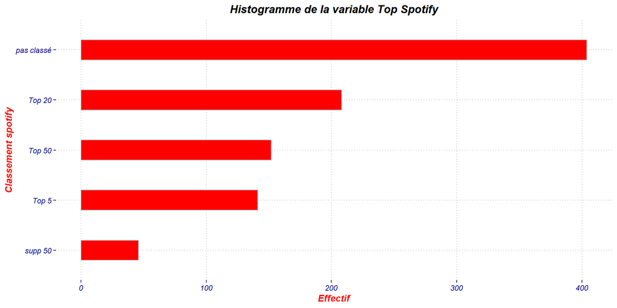

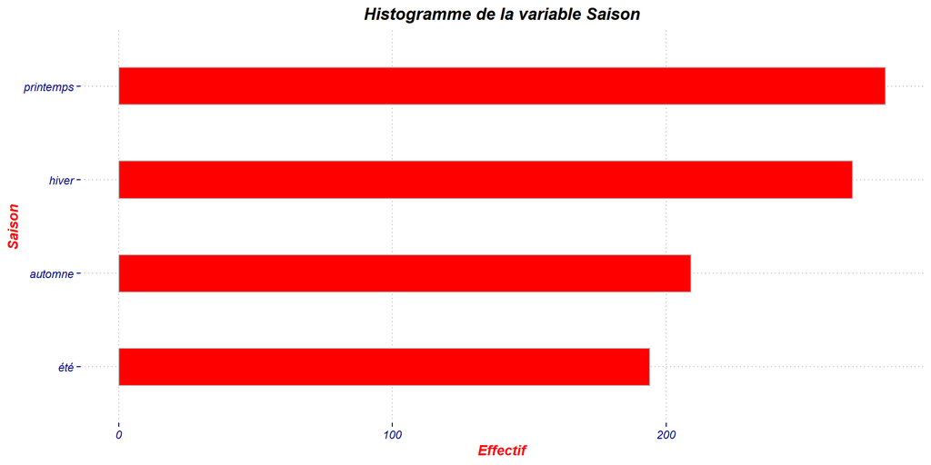

## Viabilité de l’AFC

- Tableau de contingence Chart et Saison
- test du $chi^{2}$

|  | automne | été | hiver | printemps | Total |
| --- | --- | --- | --- | --- | --- |
| Top 5 | 27 | 26 | 37 | 51 | 141 |
| Top 20 | 49 | 43 | 52 | 64 | 208 |
| Top 50 | 19 | 44 | 47 | 42 | 152 |
| supp 50 | 8 | 15 | 13 | 10 | 46 |
| pas classé | 106 | 66 | 119 | 113 | 404 |
| Total | 209 | 194 | 268 | 280 | 951 |

**Résultat du test**

| X-squared | 28.3452103 |
| --- | --- |
| df | 12.0000000 |
| p.value | 0.0049233 |

**Contribution au** $chi^{2}$

|  | automne | été | hiver | printemps | Total |
| --- | --- | --- | --- | --- | --- |
| Top 5 | 1.81 | 0.94 | 0.66 | 7.65 | 11.06 |
| Top 20 | 0.83 | 0.03 | 2.63 | 0.44 | 3.93 |
| Top 50 | 21.91 | 19.21 | 1.43 | 0.60 | 43.15 |
| supp 50 | 1.55 | 11.86 | 0.00 | 3.27 | 16.68 |
| pas classé | 11.77 | 11.53 | 0.82 | 1.05 | 25.18 |
| Total | 37.89 | 43.56 | 5.55 | 13.00 | 100.00 |

## Profils colonnes

- Tableau
- Graphique empilé

|  | automne | été | hiver | printemps | Total |
| --- | --- | --- | --- | --- | --- |
| Top 5 | 12.92 | 13.40 | 13.81 | 18.21 | 14.83 |
| Top 20 | 23.44 | 22.16 | 19.40 | 22.86 | 21.87 |
| Top 50 | 9.09 | 22.68 | 17.54 | 15.00 | 15.98 |
| supp 50 | 3.83 | 7.73 | 4.85 | 3.57 | 4.84 |
| pas classé | 50.72 | 34.02 | 44.40 | 40.36 | 42.48 |
| Total | 100.00 | 100.00 | 100.00 | 100.00 | 100.00 |

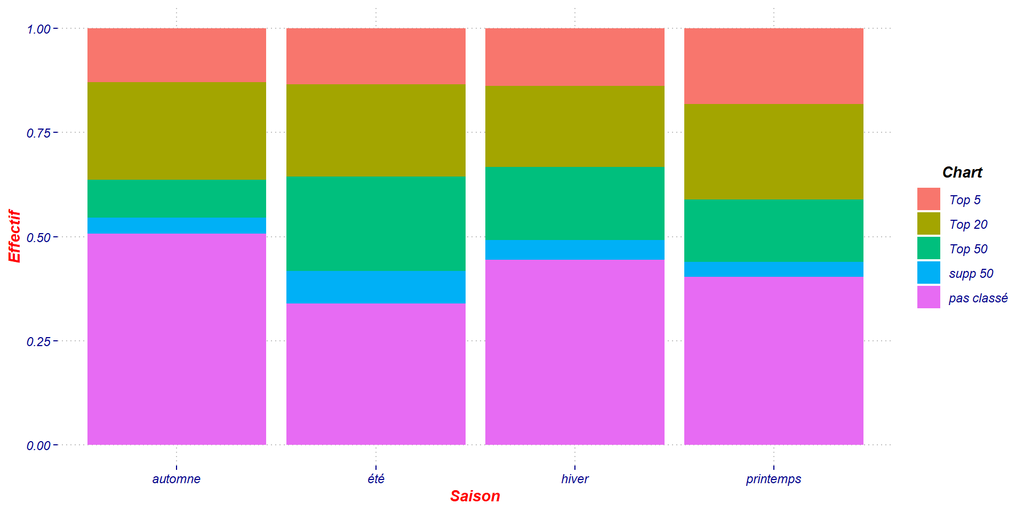

## Profil des lignes

- Tableau
- Graphique empilé

|  | automne | été | hiver | printemps | Total |
| --- | --- | --- | --- | --- | --- |
| Top 5 | 19.15 | 18.44 | 26.24 | 36.17 | 100 |
| Top 20 | 23.56 | 20.67 | 25.00 | 30.77 | 100 |
| Top 50 | 12.50 | 28.95 | 30.92 | 27.63 | 100 |
| supp 50 | 17.39 | 32.61 | 28.26 | 21.74 | 100 |
| pas classé | 26.24 | 16.34 | 29.46 | 27.97 | 100 |
| Total | 21.98 | 20.40 | 28.18 | 29.44 | 100 |

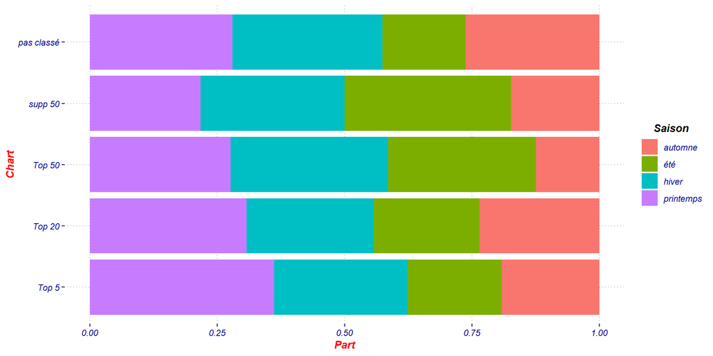

## Mise en place de l’AFC

- Inertie des axe
- Parts cumulées croissantes

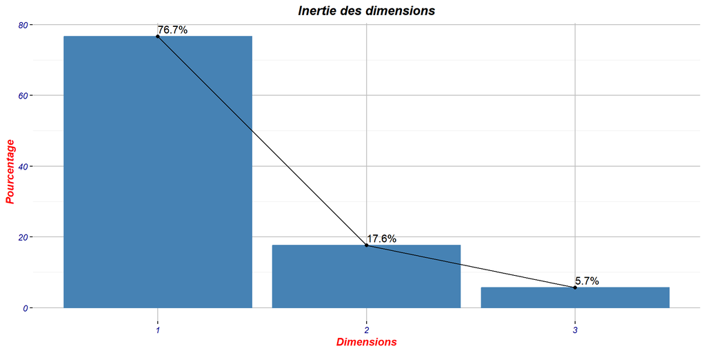

|  | F1 | F2 | F3 |
| --- | --- | --- | --- |
| Parts de Variance | 76.68 | 17.64 | 5.68 |
| Parts cumulées | 76.68 | 94.32 | 100.00 |